# Nature and DRT Report

[Spencer Castro](http://spencercastro.com)

11/18/2016

## Examining Accuracy and Reaction Time in a Go-NoGo Detection Response Task

- Indoors
- Outdoors, during exposure to Nature
- Indoors, Post exposure to Nature

We analysed the Accuracy and Reaction Time in responding to the Go-NoGo task as a measure of attention capacity during these three periods. We hypothesized that exposure to Nature and deprivation from technology may increase performance in this simple task and furthermore, should correlate with EEG measurements in oscillations of the midline frontal nodes at the Theta frequency.

```r
source("Load_Data.R") #Get the functions for loading the data
combined.data <- CombineData() #Save output of function for combining csv files
clean.data <- CleanData(combined.data) #Save output of function for cleaning data

clean <- clean.data %>%
  filter(isPractice == "no") %>%
  group_by(subid,condition,r1g0) %>%
  dplyr::mutate(falsealarm = ifelse(pressCount == 1 & r1g0 == "r", 1,0)) %>%
  dplyr::mutate(miss = ifelse(pressCount == 0 & r1g0 == "g", 1,0)) %>%
  dplyr::mutate(totalerrors = miss + falsealarm) %>%
  dplyr::mutate(correct = ifelse(totalerrors == 0, 1,0))

cleanrt <- clean %>%
  filter(rt > 100 & rt < 2000)

#summary of Signal, Noise, Hits and False Alarms
aprime <- clean %>%
  select(subid,condition,r1g0,correct,falsealarm)%>%
  group_by(subid,condition,r1g0) %>%
  dplyr::summarise(hitrate = mean(correct), farate = mean(falsealarm)) #Get summaries of hitrate and false alarm rate
hitrate1 <- aprime[c(TRUE,FALSE),]$hitrate #Get just the hits to green light
farate1 <- aprime[aprime$r1g0 == "r",]  #Get just the false alarms to red light (next line too)
farate2 <- farate1$farate
aprime1 <- aprime %>%
  group_by(subid,condition) %>%
  summarise(hitrate = mean(hitrate),farate = mean(farate)) #Prepare a dataframe for hitrate1 and farate1
aprime1$hitrate <- hitrate1 #update the hitrate column wit correct hitrates
aprime1$farate <- farate2 #update the false alarm column with correct false alarm rates
aprime2 <- Getaprime(aprime1) #Run the function Getaprime to append A' scores to the dataframe
aprimeclean <- aprime2 %>%
  filter(aprimescore > .5) #Get rid of the bad participants

# Get some summaries with Error Bars -----------------------------------------------------
#Accuracy by light and condition
datac <- summarySEwithin(clean, measurevar ="correct", withinvars = c("condition","r1g0"), idvar = "subid")
#Accuracy by condition
datac1 <- summarySEwithin(clean, measurevar ="correct", withinvars = c("condition"), idvar = "subid")
#A' Score by condition
dataca <- summarySE(aprimeclean, measurevar = "aprimescore", groupvars = "condition", na.rm = TRUE)
#Reaction time be correct response and condition
datart <- summarySEwithin(cleanrt, measurevar ="rt", withinvars = c("condition","correct"), idvar = "subid")
```

## Accuracy Plots

Participants had four possible responses in the DRT Go-NoGo task:

1. Correct Response to the Green Vibro-tactile device (Hit)
2. No Response to the Green Vibro-Tactile Device (Miss)
3. Incorrect Response to the Red Vibro-Tactile Device (False Alarm)
4. No Response to the Red Vibro-Tactile Device (Correct Rejection)

Below we have graphed the responses for the task by vibro-tactile device (R/G), by Condition, and the A’ score by condition. Error bars are 95% confidence intervals.

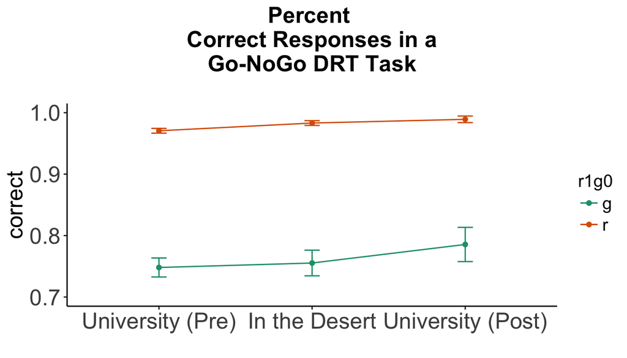

Fig. 1. The percent of correct responses to the red vibro-tactile device, (Correct Rejections) and the green vibro-tactile device (Hits).

```r
figcap1 <- "Fig. 1. The percent of correct responses to the red vibro-tactile device, (Correct Rejections) and the green vibro-tactile device (Hits)."

accplot2 <- ggplot(datac, aes(x = condition, y=correct, colour = r1g0, group = r1g0)) +
  geom_point(stat = "identity") +
  geom_line() +
  theme_classic() +  my.axis.font + xlab("Condition") + coord_cartesian(ylim=c(.7,1)) +
  geom_errorbar(width = .1,
                aes(ymin=correct-ci, ymax=correct+ci)) + xlab("") +
  ggtitle("Percent \n Correct Responses in a \n Go-NoGo DRT Task \n") +
  scale_color_brewer(type = "qual", palette = 2,direction = 1) +
  scale_x_discrete(labels = c("University (Pre)", "In the Desert", "University (Post)"))

accplot2
```

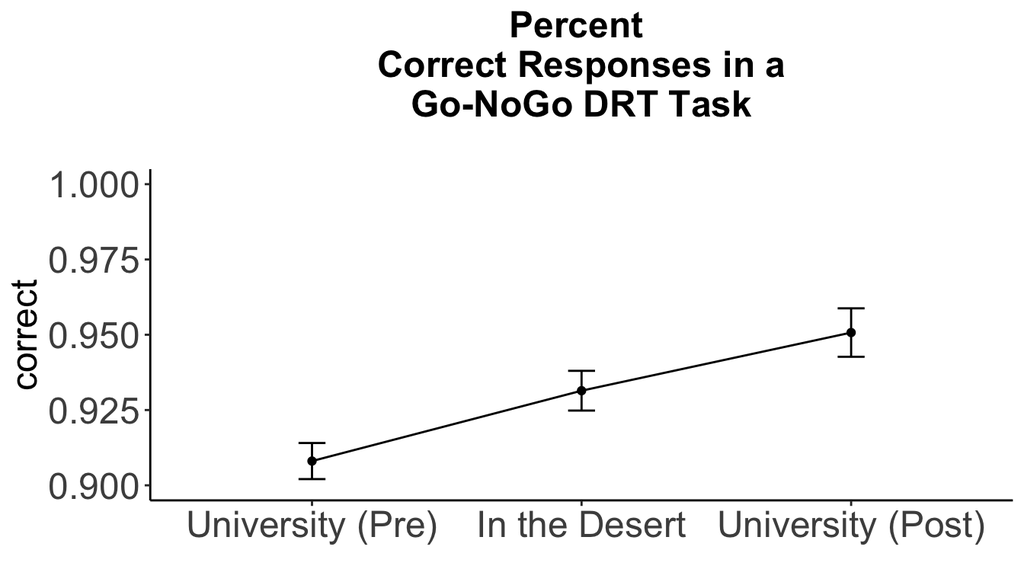

Fig. 2. The percent of correct responses (either correct rejections or hits) to the Go-NoGo task.

```r
figcap2 <- "Fig. 2. The percent of correct responses (either correct rejections or hits) to the Go-NoGo task."

accplot3 <- ggplot(datac1, aes(x = condition, y=correct, group = 1)) +
  geom_line() +
  geom_point(stat = "identity") +
  theme_classic() +  my.axis.font + xlab("Condition") + coord_cartesian(ylim=c(.9,1)) +
  geom_errorbar(width = .1,
                aes(ymin=correct-ci, ymax=correct+ci)) + xlab("") +
  ggtitle("Percent \n Correct Responses in a \n Go-NoGo DRT Task \n") +
  scale_color_brewer(type = "qual", palette = 2,direction = 1) +
  scale_x_discrete(labels = c("University (Pre)", "In the Desert", "University (Post)"))
accplot3
```

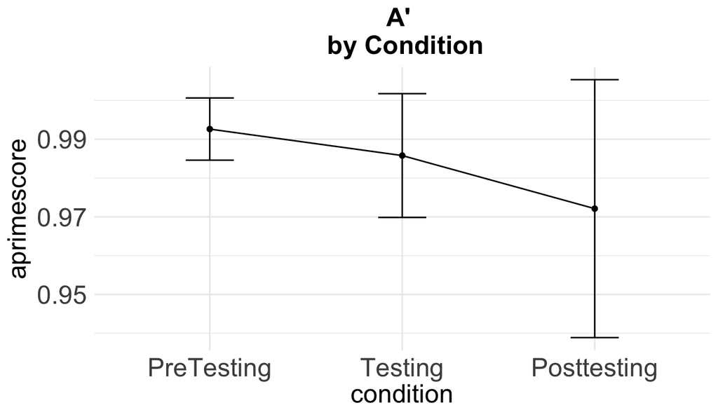

Fig. 3. The average A’ score for participants across the three conditions of pretest, test, and posttest.

```r
figcap3 <- "Fig. 3. The average A' score for participants across the three conditions of pretest, test, and posttest."

accplot5 <- ggplot(dataca, aes(x = condition, y=aprimescore, group = 1)) +
  geom_line() +
  geom_point(stat = "identity") + theme_minimal() +
  my.axis.font + ggtitle("A\' \n by Condition") +
  geom_errorbar(position=position_dodge(.9), width = .25,
                aes(ymin=aprimescore-ci, ymax=aprimescore+ci))
accplot5
```

## Statistical Analysis of Accuracy

Here we used a linear mixed model fit by Restricted Maximum Likelihood (REML), which bases estimates of likelihood from a transformed dataset so that nuisance parameters have no effect (Harville, 1977).

```r
# Simple Statistics -------------------------------------------------------
require(lmerTest)

#Errors first
clean.mean <- clean %>%
  group_by(subid,condition) %>%
  dplyr::summarise(perc_correct = mean(correct)*100) %>%
  filter(perc_correct > 50)

acc.lm <- with(as.data.frame(clean.mean), lmer(perc_correct ~ condition  + (1|subid)),na.omit())

summary(acc.lm)
```

```
## Linear mixed model fit by REML t-tests use Satterthwaite approximations
##   to degrees of freedom [lmerMod]
## Formula: perc_correct ~ condition + (1 | subid)
##
## REML criterion at convergence: 474.6
##
## Scaled residuals:
##     Min      1Q  Median      3Q     Max
## -4.3483  0.0336  0.3826  0.5607  0.6612
##
## Random effects:
##  Groups   Name        Variance Std.Dev.
##  subid    (Intercept)  0.00    0.000
##  Residual             40.93    6.397
## Number of obs: 74, groups:  subid, 26
##
## Fixed effects:
##                      Estimate Std. Error     df t value Pr(>|t|)
## (Intercept)            99.286      1.334 71.000  74.430   <2e-16 ***
## conditionTesting       -2.873      1.848 71.000  -1.554   0.1246
## conditionPosttesting   -3.516      1.831 71.000  -1.920   0.0589 .
## ---
## Signif. codes:  0 '***' 0.001 '**' 0.01 '*' 0.05 '.' 0.1 ' ' 1
##
## Correlation of Fixed Effects:
##             (Intr) cndtnT
## condtnTstng -0.722
## cndtnPsttst -0.728  0.526
```

```r
with(as.data.frame(clean.mean), lmer(perc_correct ~ condition  + (1|subid)),na.omit()) %>% anova()
```

```
## Analysis of Variance Table of type III  with  Satterthwaite
## approximation for degrees of freedom
##           Sum Sq Mean Sq NumDF DenDF F.value Pr(>F)
## condition 167.66  83.832     2    71  2.0483 0.1365
```

In summary, there are no significant effects of condition upon the percent of correct responses (either correct rejections or hits).

## Reaction Time Plots

The following plots show Reaction Times for all **Hits** and **False Alarms**. The proportion of Hits to False Alarms is very large, which is reflected in the 95% confidence interval error bars.

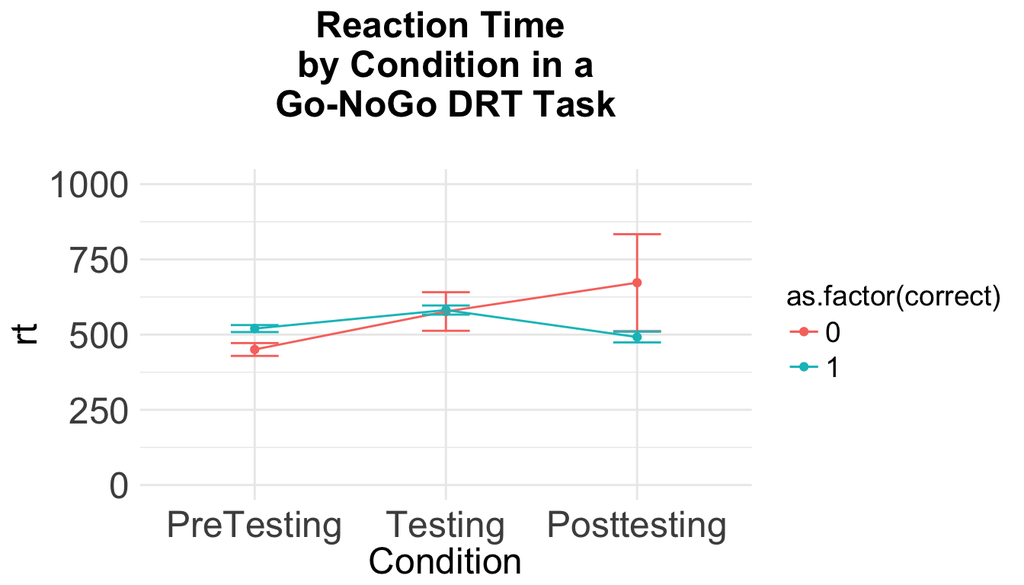

Fig. 4. The average RT for participants by condition, split by Hits **(1)** and false alarms **(0)**.

```r
#Reaction Time
figcap4 <- "Fig. 4. The average RT for participants by condition, split by Hits <b>(1)</b> and false alarms <b>(0)</b>."
rtplot2 <- ggplot(datart, aes(x = as.factor(condition),
                              y=rt, color = as.factor(correct), group = as.factor(correct))) +
  geom_point(stat = "identity", aes(color = as.factor(correct))) +
  geom_line() +
  ylim(0,1000) + theme_minimal() +  my.axis.font +
  xlab("Condition") + scale_fill_brewer(type = "qual", palette = 2,direction = 1) +
  geom_errorbar(width = .25,
                aes(ymin=rt-ci, ymax=rt+ci)) +
  ggtitle("Reaction Time \n by Condition in a \n Go-NoGo DRT Task \n")
rtplot2
```

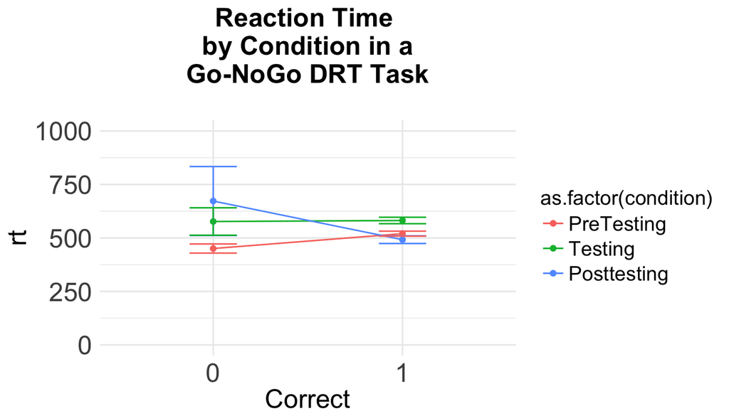

Fig. 5. The average RT for participants in Hits **(1)** and False Alarms **(0)** across the conditions of pretest, test, and posttest.

```r
figcap5 <- "Fig. 5. The average RT for participants in Hits <b>(1)</b> and False Alarms <b>(0)</b> across the conditions of pretest, test, and posttest."
rtplot3 <- ggplot(datart, aes(x = as.factor(correct), y=rt,
                              color = as.factor(condition),
                              group = as.factor(condition))) +
  geom_point(stat = "identity",
             aes(color = as.factor(condition))) +
  geom_line() +
  ylim(0,1000) + theme_minimal() +  my.axis.font +
  xlab("Correct") + scale_fill_brewer(type = "qual", palette = 2,direction = 1) +
  geom_errorbar(width = .25,
                aes(ymin=rt-ci, ymax=rt+ci)) +
  ggtitle("Reaction Time \n by Condition in a \n Go-NoGo DRT Task \n")
rtplot3
```

## Statistical Analysis of Reaction Time

Here we used a linear mixed model fit by Restricted Maximum Likelihood (REML), which bases estimates of likelihood from a transformed dataset so that nuisance parameters have no effect (Harville, 1977).

```r
rt.lm <- with(as.data.frame(clean), lmer(rt ~ condition * correct  + (1|subid)),na.omit())

summary(rt.lm)
```

```
## Linear mixed model fit by REML t-tests use Satterthwaite approximations
##   to degrees of freedom [lmerMod]
## Formula: rt ~ condition * correct + (1 | subid)
##
## REML criterion at convergence: 226314.6
##
## Scaled residuals:
##     Min      1Q  Median      3Q     Max
## -1.5646 -0.3820 -0.2787 -0.1864 17.4555
##
## Random effects:
##  Groups   Name        Variance Std.Dev.
##  subid    (Intercept)  2754     52.47
##  Residual             97326    311.97
## Number of obs: 15798, groups:  subid, 26
##
## Fixed effects:
##                               Estimate Std. Error        df t value
## (Intercept)                    106.486     20.247   287.000   5.259
## conditionTesting                 8.121     23.070 15643.000   0.352
## conditionPosttesting           255.627     26.351 13846.000   9.701
## correct                         14.350     18.521 10519.000   0.775
## conditionTesting:correct       -14.840     24.162 15586.000  -0.614
## conditionPosttesting:correct  -282.702     27.359 13660.000 -10.333
##                              Pr(>|t|)
## (Intercept)                  2.83e-07 ***
## conditionTesting                0.725
## conditionPosttesting          < 2e-16 ***
## correct                         0.438
## conditionTesting:correct        0.539
## conditionPosttesting:correct  < 2e-16 ***
## ---
## Signif. codes:  0 '***' 0.001 '**' 0.01 '*' 0.05 '.' 0.1 ' ' 1
##
## Correlation of Fixed Effects:
##             (Intr) cndtnT cndtnP corrct cndtT:
## condtnTstng -0.529
## cndtnPsttst -0.585  0.407
## correct     -0.833  0.586  0.654
## cndtnTstng:  0.515 -0.962 -0.392 -0.620
## cndtnPstts:  0.578 -0.398 -0.972 -0.691  0.417
```

```r
with(as.data.frame(clean), lmer(rt ~ condition * correct  + (1|subid)),na.omit()) %>% anova()
```

```
## Analysis of Variance Table of type III  with  Satterthwaite
## approximation for degrees of freedom
##                     Sum Sq Mean Sq NumDF DenDF F.value    Pr(>F)
## condition         10669185 5334592     2 14736  54.812 < 2.2e-16 ***
## correct            5228641 5228641     1 12031  53.723 2.456e-13 ***
## condition:correct 11995654 5997827     2 14617  61.626 < 2.2e-16 ***
## ---
## Signif. codes:  0 '***' 0.001 '**' 0.01 '*' 0.05 '.' 0.1 ' ' 1
```

When we analyze the linear mixed model using an analysis of variance we find significant effects of condition, correctness of response, and a condition by correct response interaction.